# Sesión 5

## EDA

EDA significa Exploratory Data Analysis, es un término acuñado por John Tukey para referirse al análisis estadístico inicial al que se deben someter los datos que se obtienen para poder identificar ptrones y características generales de los datos, tendencias, características numéricas, etc. y tener un mayor entendimiento y conocimiento inicial para formular preguntas correctas.

Esta fase también se conoce actualmente como análisis estadístico descriptivo de los datos y tiene las siguientes finalidades:

- Maximizar la visión sobre el conjunto de datos.
- descubrir estructuras de datos subyacentes
- identificar las variables que son más relevantes
- detectar anomalías y valores atípicos
- probar los supuestos subyacentes de los datos
- desarrollar modelos adecuados.

La mejor manera de llevar a cabo un análisis exploratorio es hacerlo de *manera interactiva*, junto con el paquete que usamos, e ir anotando las características más relevantes de la información, pero también las acciones que llevamos a cabo para que podamos reproducir nuestro análisis.

### Análisis Descriptivo

Para poder hacer el análisis trabajar con tres bloques separados puede no ser muy práctico. Resulta mejor unir los archivos, utilizando el campo que tengan en común como una especie de “llave” para unirlos. La base de usuarios tiene `user_id`, como la base de califs, así que el id del usuario se puede usar para unir las bases, y ya unidas, podemos usar `movie_id` que esta tanto en califs como en pelis. De este modo las tres bases se pueden relacionar:

```r
# Es recomendable entender las opciones de la función merge para entender qué es lo que estamos haciendo
final <- merge(merge(usuarios,califs), pelis)
head(final, 20) # muestra los primeros registros
```

```
   pelicula_id usuario_id sexo edad ocupacion    CP rating timestamp           titulo                      genero
1            1       3900    F   25        14 55343      5 965875114 Toy Story (1995) Animation|Children's|Comedy
2            1       4561    F   25         9 84037      5 964497430 Toy Story (1995) Animation|Children's|Comedy
3            1       3113    M   25        10 55414      4 969466395 Toy Story (1995) Animation|Children's|Comedy
4            1       3403    M   35         5 48342      3 967427541 Toy Story (1995) Animation|Children's|Comedy
5            1       3841    M   45        18 26101      2 965996269 Toy Story (1995) Animation|Children's|Comedy
6            1        739    M   35        12 55803      5 975475262 Toy Story (1995) Animation|Children's|Comedy
7            1       2029    F   25        12 10011      5 974670331 Toy Story (1995) Animation|Children's|Comedy
8            1       6032    M   45         7 55108      4 956718127 Toy Story (1995) Animation|Children's|Comedy
9            1       1448    F   25         3 17522      5 976138891 Toy Story (1995) Animation|Children's|Comedy
10           1       5359    M   18        16 27705      5 960547997 Toy Story (1995) Animation|Children's|Comedy
11           1        420    M   35         1 55406      4 983206889 Toy Story (1995) Animation|Children's|Comedy
12           1        595    M   25         7 10019      4 975896378 Toy Story (1995) Animation|Children's|Comedy
13           1       1271    F   45         6 54401      5 974815150 Toy Story (1995) Animation|Children's|Comedy
14           1       5560    F   35        17 98036      5 959375609 Toy Story (1995) Animation|Children's|Comedy
15           1       2135    M   50         1 01778      5 974641815 Toy Story (1995) Animation|Children's|Comedy
16           1       3182    M   25        12 12866      2 968779770 Toy Story (1995) Animation|Children's|Comedy
17           1        590    F   35         6 98032      5 975913115 Toy Story (1995) Animation|Children's|Comedy
18           1       2688    M   25        17 54915      4 978835035 Toy Story (1995) Animation|Children's|Comedy
19           1       3196    F   18         4 45219      4 970939946 Toy Story (1995) Animation|Children's|Comedy
20           1       2242    M   18         4 60115      4 974596992 Toy Story (1995) Animation|Children's|Comedy
```

¿Qué podemos hacer para contestar a estas preguntas? Justo es parte de lo que se llama “ciencia de datos”, y ya tenemos algunos elementos para poder contestar a estas preguntas con lo que sabemos de R.

Trataremos de responder a las preguntas una por una a continuación, y veremos los pasos que tenemos que seguir para responderlas.

### ¿Qué películas tienen más de 2000 ratings?

```r
Frecuencias <- table(final$titulo)
A <- Frecuencias[Frecuencias > 2000]
```

### ¿Cuál es el rating promedio de una película por grupos de sexo y edad para esas películas?

Primero separamos las películas que nos interesan

```r
mejor_calificadas <- subset(final,final$titulo %in% names(A))
head(mejor_calificadas)
```

```
  pelicula_id usuario_id sexo edad ocupacion    CP rating timestamp           titulo                      genero
1           1       3900    F   25        14 55343      5 965875114 Toy Story (1995) Animation|Children's|Comedy
2           1       4561    F   25         9 84037      5 964497430 Toy Story (1995) Animation|Children's|Comedy
3           1       3113    M   25        10 55414      4 969466395 Toy Story (1995) Animation|Children's|Comedy
4           1       3403    M   35         5 48342      3 967427541 Toy Story (1995) Animation|Children's|Comedy
5           1       3841    M   45        18 26101      2 965996269 Toy Story (1995) Animation|Children's|Comedy
6           1        739    M   35        12 55803      5 975475262 Toy Story (1995) Animation|Children's|Comedy
```

Podemos usar la función `tapply` que hemos visto antes, parecida a un tabla dinámica en Excel. El resultado lo convertimos a dataframe para poder trabajar como si fueran nuevas bases de datos.

```r
ratings_por_sexo <- as.data.frame(with(mejor_calificadas, tapply(rating, list(titulo, sexo), mean, na.rm=T)))
ratings_por_sexo
```

```
                                                             F        M
Alien (1979)                                          3.888252 4.216119
American Beauty (1999)                                4.238901 4.347301
Back to the Future (1985)                             3.932707 4.009259
Being John Malkovich (1999)                           4.159930 4.113636
Braveheart (1995)                                     4.016484 4.297839
E.T. the Extra-Terrestrial (1982)                     4.089850 3.920264
Fargo (1996)                                          4.217656 4.267780
Forrest Gump (1994)                                   4.045031 4.105806
Ghostbusters (1984)                                   3.833962 3.928528
Godfather, The (1972)                                 4.314700 4.583333
Groundhog Day (1993)                                  3.735562 4.041358
Jurassic Park (1993)                                  3.579407 3.814197
L.A. Confidential (1997)                              4.106007 4.256678
Matrix, The (1999)                                    4.128405 4.362235
Men in Black (1997)                                   3.817844 3.719000
Princess Bride, The (1987)                            4.342767 4.288942
Pulp Fiction (1994)                                   4.071956 4.346839
Raiders of the Lost Ark (1981)                        4.332168 4.520597
Saving Private Ryan (1998)                            4.114783 4.398941
Schindler's List (1993)                               4.562602 4.491415
Shakespeare in Love (1998)                            4.181704 4.099936
Shawshank Redemption, The (1994)                      4.539075 4.560625
Silence of the Lambs, The (1991)                      4.271955 4.381944
Sixth Sense, The (1999)                               4.477410 4.379944
Star Wars: Episode I - The Phantom Menace (1999)      3.328326 3.431054
Star Wars: Episode IV - A New Hope (1977)             4.302937 4.495307
Star Wars: Episode V - The Empire Strikes Back (1980) 4.106481 4.344577
Star Wars: Episode VI - Return of the Jedi (1983)     3.865237 4.069058
Terminator 2: Judgment Day (1991)                     3.785088 4.115367
Terminator, The (1984)                                3.899729 4.205899
Toy Story (1995)                                      4.187817 4.130552
```

```r
ratings_por_edad <- as.data.frame(with(mejor_calificadas, tapply(rating, list(titulo, edad), mean, na.rm=T)))
ratings_por_edad
```

```
                                                             1       18       25       35       45       50       56
Alien (1979)                                          4.000000 3.922078 4.252513 4.200000 4.164894 4.109677 4.070423
American Beauty (1999)                                4.434783 4.521678 4.330585 4.231156 4.151163 4.149194 4.108696
Back to the Future (1985)                             4.014925 4.079498 3.955045 3.975238 4.000000 4.036269 3.875000
Being John Malkovich (1999)                           4.090909 4.202083 4.091703 4.156171 4.141026 3.978417 4.149425
Braveheart (1995)                                     4.192982 4.406250 4.254292 4.152318 4.119048 4.099476 3.969388
E.T. the Extra-Terrestrial (1982)                     3.653333 3.801527 3.957111 4.004202 4.085427 4.188312 4.174419
Fargo (1996)                                          4.283019 4.175166 4.235650 4.234694 4.315789 4.396985 4.440678
Forrest Gump (1994)                                   4.168539 4.100897 4.054678 4.036939 4.187166 4.090909 4.228571
Ghostbusters (1984)                                   3.881356 4.020179 3.894490 3.838407 3.966292 3.841727 3.734177
Godfather, The (1972)                                 4.471698 4.505495 4.574051 4.541935 4.357843 4.540404 4.467213
Groundhog Day (1993)                                  3.805195 3.853933 4.002230 3.983529 4.010695 3.907407 3.894118
Jurassic Park (1993)                                  3.808989 3.737523 3.702000 3.795367 3.940367 3.766839 3.911504
L.A. Confidential (1997)                              4.217391 4.248157 4.238636 4.168919 4.191176 4.277487 4.120690
Matrix, The (1999)                                    4.464646 4.446208 4.389895 4.249476 4.026316 3.920530 3.964912
Men in Black (1997)                                   3.840000 3.618677 3.665294 3.843496 3.844560 3.977901 3.862069
Princess Bride, The (1987)                            4.121212 4.318725 4.367347 4.300231 4.169697 4.084034 4.150943
Pulp Fiction (1994)                                   4.489796 4.370526 4.390244 4.150649 4.054422 3.985401 3.842105
Raiders of the Lost Ark (1981)                        4.186667 4.377682 4.578521 4.475538 4.443350 4.386905 4.403846
Saving Private Ryan (1998)                            4.378049 4.287293 4.291052 4.390873 4.364929 4.485714 4.438017
Schindler's List (1993)                               4.446429 4.472851 4.485346 4.510345 4.591549 4.565476 4.620438
Shakespeare in Love (1998)                            3.971429 4.041667 4.081986 4.174672 4.253456 4.336842 4.117647
Shawshank Redemption, The (1994)                      4.543478 4.674569 4.587699 4.487500 4.481283 4.350993 4.425743
Silence of the Lambs, The (1991)                      4.283019 4.378261 4.406748 4.298039 4.283582 4.157895 4.413793
Sixth Sense, The (1999)                               4.275229 4.315175 4.435551 4.457082 4.465517 4.421769 4.367816
Star Wars: Episode I - The Phantom Menace (1999)      3.659341 3.495108 3.372093 3.331683 3.348684 3.495798 3.385714
Star Wars: Episode IV - A New Hope (1977)             4.267327 4.427046 4.572695 4.354633 4.386831 4.460465 4.250000
Star Wars: Episode V - The Empire Strikes Back (1980) 4.184783 4.442142 4.390306 4.153846 4.137168 4.033981 4.123894
Star Wars: Episode VI - Return of the Jedi (1983)     4.130000 4.182594 4.058201 3.887273 3.948357 3.786458 3.944444
Terminator 2: Judgment Day (1991)                     4.227273 4.058601 4.024839 4.129771 4.056995 4.066667 3.871429
Terminator, The (1984)                                3.972973 3.840617 4.192351 4.307692 4.205128 4.343511 3.962963
Toy Story (1995)                                      3.919643 4.017857 4.201266 4.302600 4.104895 4.092593 3.886792
```

```r
ratings_por_sexo_edad <- as.data.frame(with(mejor_calificadas, tapply(rating, list(titulo, edad, sexo), mean, na.rm=T)))
ratings_por_sexo_edad
```

```
                                                           1.F     18.F     25.F     35.F     45.F     50.F     56.F      1.M     18.M
Alien (1979)                                          3.428571 3.767442 4.054264 3.862069 3.911111 3.518519 3.727273 4.117647 3.947170
American Beauty (1999)                                4.033333 4.467742 4.263158 4.160494 4.127907 4.074627 4.018519 4.629032 4.540643
Back to the Future (1985)                             3.736842 3.899160 3.932203 3.910448 4.016667 4.100000 3.809524 4.125000 4.139276
Being John Malkovich (1999)                           3.750000 4.278261 4.095833 4.100000 4.326531 4.176471 4.368421 4.166667 4.178082
Braveheart (1995)                                     4.062500 4.121739 4.056701 3.950495 3.963636 3.837209 3.863636 4.243902 4.482517
E.T. the Extra-Terrestrial (1982)                     3.696970 3.936842 4.096774 4.080000 4.107692 4.428571 4.583333 3.619048 3.758389
Fargo (1996)                                          3.727273 4.100917 4.245059 4.197080 4.138462 4.321429 4.730769 4.428571 4.198830
Forrest Gump (1994)                                   4.000000 3.984848 4.065502 3.893805 4.088235 4.100000 4.600000 4.263158 4.149682
Ghostbusters (1984)                                   3.736842 3.831683 3.737968 3.825688 4.155172 3.916667 3.800000 3.950000 4.075362
Godfather, The (1972)                                 4.142857 4.212121 4.392638 4.324074 4.080000 4.529412 4.193548 4.589744 4.570470
Groundhog Day (1993)                                  3.481481 3.484127 3.851064 3.798507 3.820896 3.690476 3.703704 3.980000 4.000000
Jurassic Park (1993)                                  3.680000 3.521739 3.585714 3.576923 3.929825 3.238095 3.450000 3.859375 3.795775
L.A. Confidential (1997)                              3.666667 4.033333 4.131068 4.090164 4.112903 4.250000 4.035714 4.300000 4.309148
Matrix, The (1999)                                    4.352941 4.116667 4.310881 4.000000 3.875000 3.730769 3.800000 4.487805 4.534676
Men in Black (1997)                                   3.931034 3.747826 3.777778 3.867347 3.836735 3.916667 4.076923 3.802817 3.581454
Princess Bride, The (1987)                            4.238095 4.413043 4.451737 4.301724 4.115385 3.970588 3.937500 4.066667 4.282967
Pulp Fiction (1994)                                   4.555556 4.027273 4.196347 3.969072 3.840000 3.885714 4.136364 4.475000 4.473973
Raiders of the Lost Ark (1981)                        4.000000 4.136842 4.417040 4.411290 4.277778 4.405405 4.130435 4.237288 4.439353
Saving Private Ryan (1998)                            4.071429 3.913793 4.116505 4.151786 4.258065 4.454545 4.093750 4.441176 4.388759
Schindler's List (1993)                               4.533333 4.431034 4.481308 4.627273 4.704225 4.765957 4.714286 4.414634 4.487730
Shakespeare in Love (1998)                            4.272727 4.087248 4.206522 4.197452 4.234568 4.305085 3.953488 3.702703 4.017668
Shawshank Redemption, The (1994)                      4.538462 4.603306 4.605150 4.378151 4.548387 4.387755 4.633333 4.545455 4.699708
Silence of the Lambs, The (1991)                      4.083333 4.384000 4.384615 4.212903 3.943662 3.886364 4.538462 4.341463 4.376119
Sixth Sense, The (1999)                               4.225806 4.218045 4.605042 4.489051 4.603774 4.577778 4.444444 4.294872 4.349081
Star Wars: Episode I - The Phantom Menace (1999)      3.571429 3.356436 3.258824 3.255814 3.478261 3.238095 3.571429 3.698413 3.529268
Star Wars: Episode IV - A New Hope (1977)             4.160000 4.149123 4.410480 4.192857 4.415385 4.411765 4.260870 4.302632 4.497768
Star Wars: Episode V - The Empire Strikes Back (1980) 3.850000 4.165289 4.141700 4.035211 4.127273 4.090909 4.052632 4.277778 4.515284
Star Wars: Episode VI - Return of the Jedi (1983)     3.769231 3.891473 3.959184 3.651852 4.083333 3.604651 4.066667 4.256757 4.264770
Terminator 2: Judgment Day (1991)                     4.111111 3.764045 3.802139 3.731959 3.875000 3.615385 4.000000 4.245614 4.118182
Terminator, The (1984)                                4.000000 3.612903 3.858974 4.126437 4.000000 4.058824 3.571429 3.966667 3.883792
Toy Story (1995)                                      4.076923 4.086614 4.325123 4.232558 3.916667 4.033333 4.266667 3.835616 3.990654
                                                          25.M     35.M     45.M     50.M     56.M
Alien (1979)                                          4.290855 4.277778 4.244755 4.234375 4.133333
American Beauty (1999)                                4.355601 4.257471 4.162791 4.176796 4.146154
Back to the Future (1985)                             3.962092 3.997442 3.993548 4.013986 3.891566
Being John Malkovich (1999)                           4.090237 4.175084 4.056075 3.914286 4.088235
Braveheart (1995)                                     4.306233 4.210227 4.194690 4.175676 4.000000
E.T. the Extra-Terrestrial (1982)                     3.911809 3.977208 4.074627 4.098214 4.016129
Fargo (1996)                                          4.232432 4.249292 4.395833 4.426573 4.358696
```

[output cut: 9 more lines]

```
Pulp Fiction (1994)                                   4.452416 4.211806 4.164948 4.019608 3.722222
Raiders of the Lost Ark (1981)                        4.625654 4.496124 4.503356 4.381679 4.481481
Saving Private Ryan (1998)                            4.335388 4.459184 4.409396 4.492958 4.561798
Schindler's List (1993)                               4.486698 4.470769 4.535211 4.487603 4.578947
Shakespeare in Love (1998)                            4.023729 4.162791 4.264706 4.351145 4.193548
Shawshank Redemption, The (1994)                      4.581395 4.533808 4.448000 4.333333 4.338028
Silence of the Lambs, The (1991)                      4.414358 4.335211 4.469231 4.251969 4.377778
Sixth Sense, The (1999)                               4.379834 4.443769 4.404959 4.352941 4.333333
Star Wars: Episode I - The Phantom Menace (1999)      3.398363 3.352201 3.292453 3.551020 3.339286
Star Wars: Episode IV - A New Hope (1977)             4.614016 4.401235 4.376404 4.475610 4.247312
Star Wars: Episode V - The Empire Strikes Back (1980) 4.456405 4.190789 4.140351 4.018519 4.138298
Star Wars: Episode VI - Return of the Jedi (1983)     4.085489 3.963855 3.895425 3.838926 3.924731
Terminator 2: Judgment Day (1991)                     4.071111 4.220141 4.104575 4.142857 3.854839
Terminator, The (1984)                                4.263302 4.352113 4.260163 4.385965 4.021277
Toy Story (1995)                                      4.158433 4.333333 4.200000 4.115385 3.736842
```

### ¿Cuáles películas son más opuestas en rating entre hombres y mujeres?

Una manera de responder es agregar una columna de diferencias al `rating_por_sexo`.

```r
ratings_por_sexo$diferencias <- ratings_por_sexo$F - ratings_por_sexo$M
```

Para ver cuál es la máxima diferencia, podemos ordenar los registros de acuerdo a los valores de la columna `diferencias`

```r
diferencias <- ratings_por_sexo[order(ratings_por_sexo$diferencias),]
diferencias
```

```
                                                             F        M diferencias
Terminator 2: Judgment Day (1991)                     3.785088 4.115367 -0.33027936
Alien (1979)                                          3.888252 4.216119 -0.32786725
Terminator, The (1984)                                3.899729 4.205899 -0.30617037
Groundhog Day (1993)                                  3.735562 4.041358 -0.30579571
Saving Private Ryan (1998)                            4.114783 4.398941 -0.28415868
Braveheart (1995)                                     4.016484 4.297839 -0.28135518
Pulp Fiction (1994)                                   4.071956 4.346839 -0.27488283
Godfather, The (1972)                                 4.314700 4.583333 -0.26863354
Star Wars: Episode V - The Empire Strikes Back (1980) 4.106481 4.344577 -0.23809580
Jurassic Park (1993)                                  3.579407 3.814197 -0.23479061
Matrix, The (1999)                                    4.128405 4.362235 -0.23383040
Star Wars: Episode VI - Return of the Jedi (1983)     3.865237 4.069058 -0.20382093
Star Wars: Episode IV - A New Hope (1977)             4.302937 4.495307 -0.19237054
Raiders of the Lost Ark (1981)                        4.332168 4.520597 -0.18842949
L.A. Confidential (1997)                              4.106007 4.256678 -0.15067121
Silence of the Lambs, The (1991)                      4.271955 4.381944 -0.10998977
American Beauty (1999)                                4.238901 4.347301 -0.10839993
Star Wars: Episode I - The Phantom Menace (1999)      3.328326 3.431054 -0.10272763
Ghostbusters (1984)                                   3.833962 3.928528 -0.09456590
Back to the Future (1985)                             3.932707 4.009259 -0.07655190
Forrest Gump (1994)                                   4.045031 4.105806 -0.06077540
Fargo (1996)                                          4.217656 4.267780 -0.05012416
Shawshank Redemption, The (1994)                      4.539075 4.560625 -0.02155004
Being John Malkovich (1999)                           4.159930 4.113636  0.04629334
Princess Bride, The (1987)                            4.342767 4.288942  0.05382556
Toy Story (1995)                                      4.187817 4.130552  0.05726544
Schindler's List (1993)                               4.562602 4.491415  0.07118659
Shakespeare in Love (1998)                            4.181704 4.099936  0.08176791
Sixth Sense, The (1999)                               4.477410 4.379944  0.09746535
Men in Black (1997)                                   3.817844 3.719000  0.09884387
E.T. the Extra-Terrestrial (1982)                     4.089850 3.920264  0.16958646
```

Entonces las películas con mayores discrepancias, son *ET* que le gustó más a las mujeres, y *Terminator 2* que le gustó más a los hombres.

Una gráfica de este análisis se puede ver como sigue:

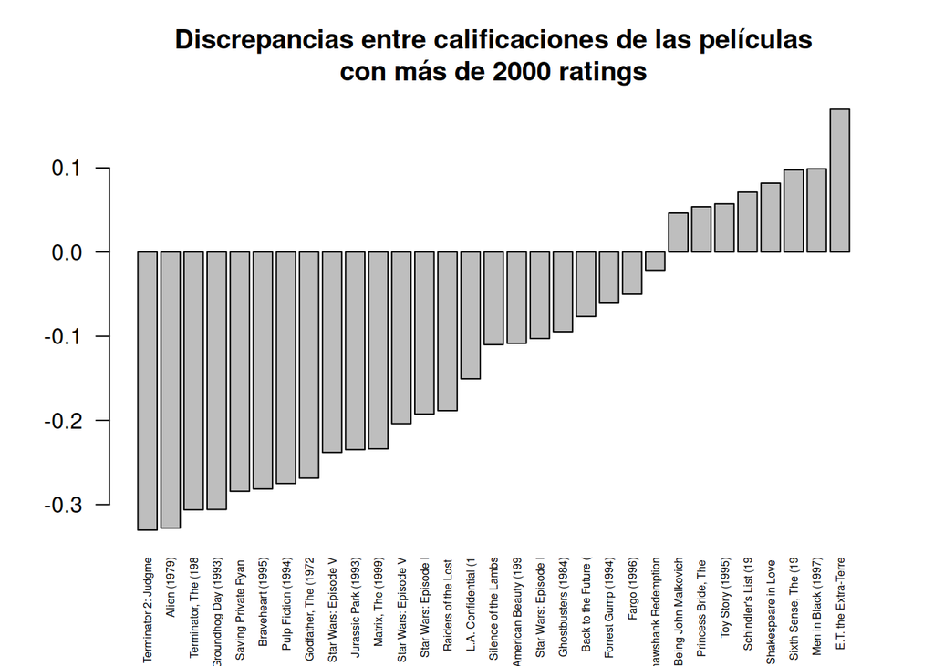

```r
barplot(height = diferencias$diferencias,names.arg = substr(rownames(diferencias),1,20), las=2,cex.names = 0.5,
        main = "Discrepancias entre calificaciones de las películas\ncon más de 2000 ratings")
```

### Diversidad de calificaciones entre películas.

Una manera de medir la controversia en las películas se puede ver a través de que tanto varían las calificaciones para una película. Podemos usar la desviación estándar como una medida de esa variabilidad, y agregarla como una variable más. Esta variable la vamos a agregar en independencia del sexo o la edad de las personas. Ahora consideraremos las 20 películas más controversiales del conjunto de películas disponibles

```r
controversiales <- data.frame(tapply(final$rating,final$titulo,sd, na.rm=T))
head(controversiales)
```

```
                              tapply.final.rating..final.titulo..sd..na.rm...T.
...And Justice for All (1979)                                         0.8781102
'burbs, The (1989)                                                    1.1077602
'Night Mother (1986)                                                  1.1186357
'Til There Was You (1997)                                             1.0201588
$1,000,000 Duck (1971)                                                1.0925629
1-900 (1994)                                                          0.7071068
```

```r
names(controversiales) <- c("sd")
controversiales$titulo <- rownames(controversiales)  # Agrego los nombres porque se pierden en el camino.
rownames(controversiales) <- NULL # y los quito como nombres de renglones para que no aparezcan dobles
controversiales <- controversiales[order(controversiales$sd,decreasing = T),]
head(controversiales,20) # Las más polémicas
```

```
           sd                                                                titulo
1225 2.828427                                                Foreign Student (1994)
793  2.309401                         Criminal Lovers (Les Amants Criminels) (1999)
362  2.121320                                                  Better Living (1998)
1017 2.121320                                                    Eaten Alive (1976)
1650 2.121320       Identification of a Woman (Identificazione di una donna) (1982)
1964 2.121320                       Living Dead Girl, The (La Morte Vivante) (1982)
2341 2.121320                                                Neon Bible, The (1995)
2515 2.121320              Paralyzing Fear: The Story of Polio in America, A (1998)
3221 2.121320                                                    Sunset Park (1996)
3265 2.121320                                                 Talk of Angels (1998)
3387 2.121320                                                     Tokyo Fist (1995)
3702 2.121320                                                      Zachariah (1971)
3511 2.081666                                 Vampyros Lesbos (Las Vampiras) (1970)
2846 2.061553                                                          Rosie (1998)
2522 2.000000                                                  Paris, France (1993)
1665 1.949359                                                 In God's Hands (1998)
3120 1.914854           Spiders, The (Die Spinnen, 1. Teil: Der Goldene See) (1919)
418  1.892969                         Black Sunday (La Maschera Del Demonio) (1960)
1514 1.825742                                                        Held Up (2000)
1897 1.799471 Late August, Early September (Fin ao\xfbt, d\xe9but septembre) (1998)
```

```r
tail(controversiales,20) # notamos que hay varias películas que no tienen una calificación.
```

```
     sd                                      titulo
3233 NA                       Superweib, Das (1996)
3256 NA                              Tainted (1998)
3276 NA                               Target (1995)
3280 NA                             Tashunga (1995)
3289 NA                          Telling You (1998)
3291 NA                            Ten Benny (1997)
3298 NA               Terror in a Texas Town (1958)
3373 NA                           Tinseltown (1998)
3434 NA                                Trois (2000)
3479 NA                     Ulysses (Ulisse) (1954)
3489 NA                           Underworld (1997)
3493 NA                  Uninvited Guest, An (2000)
3539 NA Voyage to the Beginning of the World (1997)
3543 NA                    Waiting Game, The (2000)
3554 NA                  Waltzes from Vienna (1933)
3581 NA              Wend Kuuni (God's Gift) (1982)
3611 NA                           White Boys (1999)
3639 NA                              Windows (1980)
3652 NA          With Byrd at the South Pole (1930)
3672 NA     Wooden Man's Bride, The (Wu Kui) (1994)
```

```r
tail(controversiales[!is.na(controversiales$sd),],20) # las que todos opinan igual
```

```
     sd                                                     titulo
1907  0                           Leather Jacket Love Story (1997)
1934  0                                         Light Years (1988)
2032  0                                               Macao (1952)
2153  0                           Metisse (Caf\xe9 au Lait) (1993)
2224  0                                    Moonlight Murder (1936)
2325  0                                      Naked Man, The (1998)
2327  0                               Napoleon and Samantha (1972)
2888  0                                  Santa with Muscles (1996)
3046  0                                       Smashing Time (1967)
3091  0                                       Sonic Outlaws (1995)
3127  0                Spring Fever USA (a.k.a. Lauderdale) (1989)
3193  0                                       Stranger, The (1994)
3243  0                                       Sweet Nothing (1995)
3274  0                                          Tarantella (1995)
3402  0 Torso (Corpi Presentano Tracce di Violenza Carnale) (1973)
3518  0                                       Venice/Venice (1992)
3607  0                                    Where's Marlowe? (1999)
3648  0                                      Wirey Spindell (1999)
3653  0                          With Friends Like These... (1998)
3684  0                                         Yankee Zulu (1994)
```

### ¿Cuáles son los géneros que más les gustan a las mujeres? ¿cuáles a los hombres?

Vemos que una película puede estar contada en más de un género. Para hacer una cuenta correcta, deberíamos contar una película en cada uno de los géneros en que se clasifica. Este es un ejemplo del uso de listas para hacer un análisis de datos.